# Préparation du travail

Author

Claude Grasland

## PREPARATION DU TRAVAIL

Télécharger le [dossier projet exos2](https://github.com/worldregio/datamining2025/raw/main/exos/exo2.zip) pour suivre et executer les commandes.

### Packages

On charge les packages suivants

```r
knitr::opts_chunk$set(echo = TRUE, warning= FALSE, message = FALSE, error=FALSE)

## Affichage de tableaux
library(knitr)

## Tidyverse & co
library(tidyverse)
## Data.table (pour sa fonction d'importation fread)
library(data.table)
## Information géographique
library(sf)
```

### Acquisistion du fichier INSEE individus

On constitue un fichier des individus localisés dans les communes de Paris et Petite Couronne au RP de 2021 en reprenant le programme décrit dans le [Cours n°1 de Camille Signoretto](https://camille-sisi.github.io/Data-Mining-2024/01-Base-de-donnees.html).

Le programme ci-dessous comporte la mention “eval=FALSE” car il ne dout être executé qu’une seule fois.

```r
# (1) FICHIER DE DONNEES
download.file(url="https://www.insee.fr/fr/statistiques/fichier/8268848/RP2021_indcviza.zip",
              destfile = "tmp/RP2021_indcviza.zip")

# Le fichier est  téléchargé dans un dossier temporaire  "tmp" du projet R, on va
# maintenant le dézipper et enregistrer les fichiers extraits dans le dossier data/RP2021.
unzip("tmp/RP2021_indcviza.zip", exdir = "data")

#library(data.table)
RP <- fread("data/FD_INDCVIZA_2021.csv", stringsAsFactors=TRUE)
RP <- as.data.frame(RP)

# Selection de Paris et PC
RP <- RP %>% filter(DEPT %in% c("75","92","93","94"))


saveRDS(RP, "ParisPC/RP2021/indiv2021.Rdata")

# (2) FICHIER DE METADONNEES
download.file(url="https://www.insee.fr/fr/statistiques/fichier/8268848/varmod_indcvi_2021.csv",
              destfile = "tmp/varmod_indcvi_2021.csv")
#Lecture du fichier
meta <- read.csv(file = "tmp/varmod_indcvi_2021.csv",
                 sep = ";",
                 encoding = "UTF-8",
                 stringsAsFactors = TRUE)

saveRDS(object = meta, file = "ParisPC/RP2021/meta.Rdata")
```

### Acquisition de la géométrie des IRIS

On va maintenant acquérir le fichier des unités géographiques les plus petites (IRIS) pour la zone Paris + Petite Couronne. On se servira de ce fonds de carte des IRIS pour générer ensuite ceux des unités géographiques de niveau supérieur : communes, territoires, départements …

Comme les IRIS changent au cours du temps, il faut choisir le bon “millésime” pour que la correspondance soit possible avec les données individuelles du recensement. On utilise un lien de téléchargement depuis la [base des iris millésimé accessible sur public.opendatasoft](https://public.opendatasoft.com/explore/dataset/georef-france-iris-millesime)

Comme précédemment, ce programme est à executer une seule fois d’où la mention eval=FALSE dans l’en-tête du chunk.

```r
## Lien de téléchargement IDF 2019 au forma geojson
myurl <-"https://public.opendatasoft.com/api/explore/v2.1/catalog/datasets/georef-france-iris-millesime/exports/geojson?lang=fr&refine=year%3A%222021%22&refine=reg_name%3A%22%C3%8Ele-de-France%22&facet=facet(name%3D%22reg_name%22%2C%20disjunctive%3Dtrue)&timezone=Europe%2FBerlin"

## téléchargement et conversion au format sf
geo<-st_read(myurl)

#Sélectione les variables
geo<-geo %>% select(iris_type,
                    iris_code,
                    iris_name,
                    com_code= com_arm_code,
                    com_name = com_arm_name,
                    dep_code,
                    dep_name,
                    geometry)

# remplace les listes par des vecteurs
geo <- geo %>% mutate(iris_code = as.character(iris_code),
                      iris_name = as.character(iris_name),
                      com_code = as.character(com_code),
                      com_name =as.character(com_name),
                      dep_code = as.character(dep_code),
                      dep_name = as.character(dep_name))



## Selection Paris PC
geo<-geo %>% filter(dep_code %in% c("75","92","93","94"))
#plot(geo["iris_type"])

## Sauvegarde

saveRDS(geo,"ParisPC/geom/map_iris.RDS" )
```

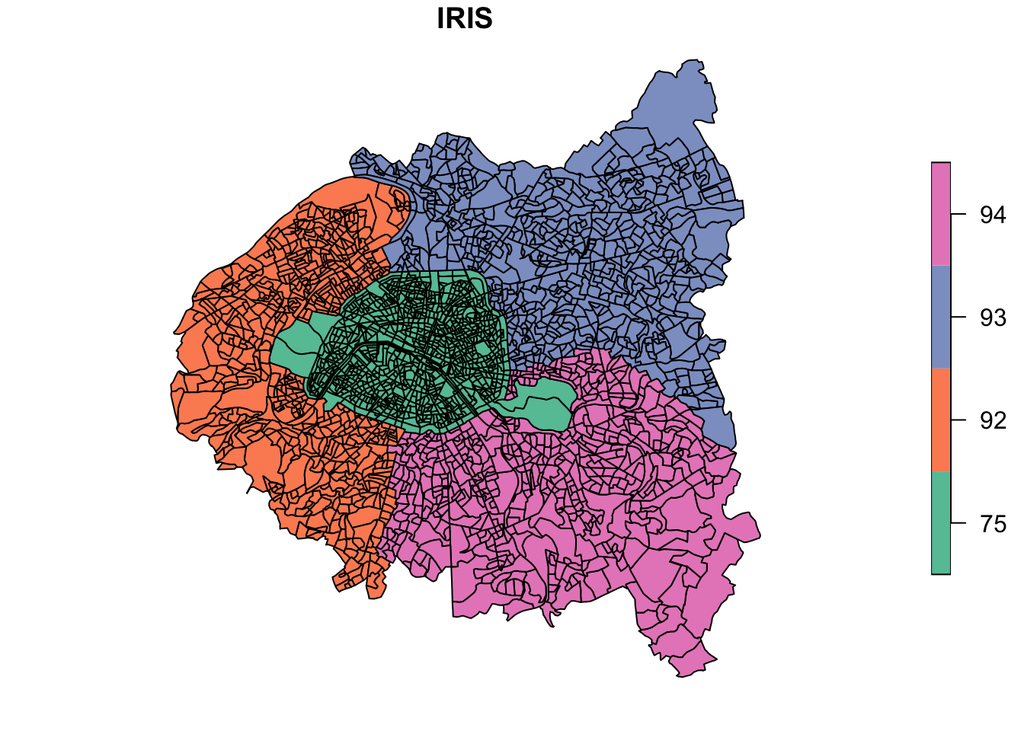

```r
## Carto rapide
map_iris <- readRDS("ParisPC/geom/map_iris.RDS")
plot(map_iris["dep_code"], main = "IRIS")
```

### Agrégation spatiale des iris en communes

On agrège par le nom et le code de la commune et on conserve le nom et le code du département.

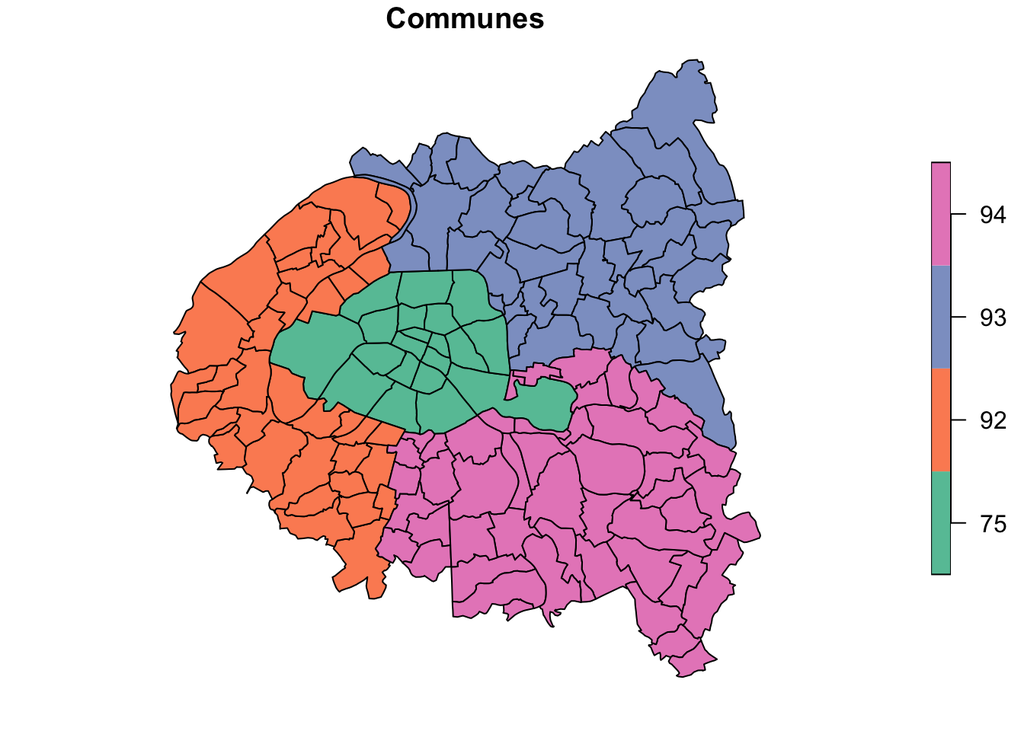

```r
map_iris <- readRDS("ParisPC/geom/map_iris.RDS")
map_com <- map_iris %>% group_by(com_code, com_name) %>%
                  summarise(dep_code = max(dep_code),
                            dep_name = max(dep_name))
plot(map_com["dep_code"], main = "Communes")
```

```r
saveRDS(map_com, "ParisPC/geom/map_com.RDS")
```

### Agrégation spatiale des iris en département

On agrège simplement par le nom et le code du département.

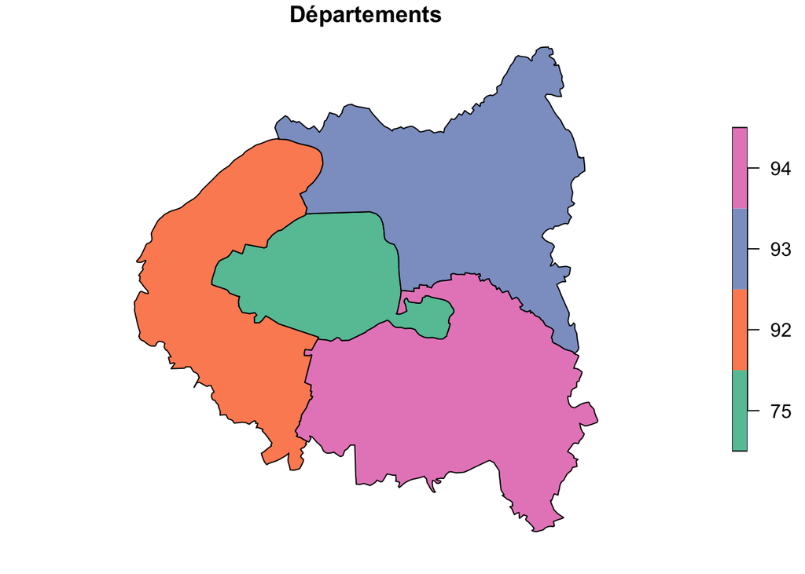

```r
map_iris <- readRDS("ParisPC/geom/map_iris.RDS")
map_dep <- map_iris %>% group_by(dep_code, dep_name) %>%
                  summarise()
plot(map_dep["dep_code"], main = "Départements")
```

```r
saveRDS(map_dep, "ParisPC/geom/map_dep.RDS")
```

### Agrégation des données RP par iris

Nous allons maintenant examiner comment agréger les données individuelles de l’INSEE par iris, commune ou département et effectuer une jointure avec les fonds de cartes que nous avons préparé. On va s’appuyer pour cela sur le [cours de datamining n°1 de Camille Signoretto](https://camille-sisi.github.io/Data-Mining-2024/05-Questions-fouille-donnees.html).

Nous l’utilisons pour créer un tableau des individus par CSP simplifiées en 5 catégories et par IRIS :

```r
# Chargement du tableau
indiv <- readRDS("ParisPC/RP2021/indiv2021.Rdata")

# Création de CSP simplifiées
indiv <- indiv %>%
  mutate(TACT5=case_when(TACT == "11" ~ "EMP",
                             TACT == "12" ~ "CHO",
                             TACT == "22" ~ "ETU",
                             TACT == "21" ~ "RET",
                             TRUE ~ "DIV"))

# Agrégation par IRIS
tab_iris_csp  <- indiv %>%
                 group_by(IRIS, TACT5) %>%
                 summarise(n = sum(IPONDI)) %>%
                 mutate(n=round(n)) %>%
                 pivot_wider(names_from = TACT5, values_from = n)
```

### Jointure des CSP avec la géométrie des IRIS

On procède à la jointure des deux fichiers iris en utilisant le code des iris.

```r
map_iris <- readRDS("ParisPC/geom/map_iris.RDS")
map_iris_csp<- left_join(map_iris, tab_iris_csp,by = c("iris_code"="IRIS"))
saveRDS(map_iris_csp, "ParisPC/geom/map_iris_CSP.RDS")
```

On examine quels IRIS ne sont pas renseignés en croisant cette information avec le type d’IRIS.

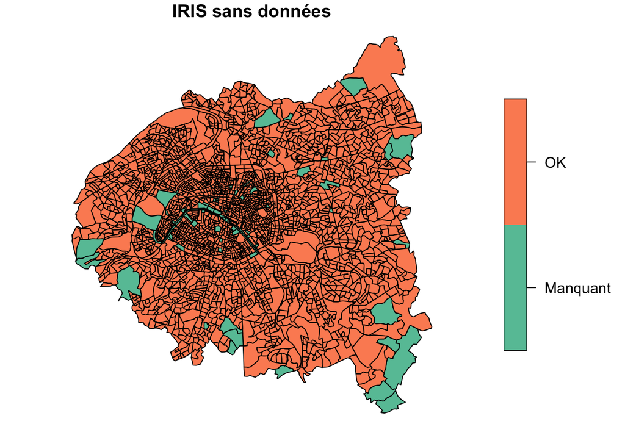

```r
map_iris_csp$missing<-case_when(is.na(map_iris_csp$CHO)  ~ "Manquant",
                                TRUE ~ "OK"
                               )
plot(map_iris_csp["missing"], main = "IRIS sans données")
```

```r
tab<-table(map_iris_csp$missing,map_iris_csp$iris_type)
addmargins(tab)
```

```
           commune iris d'activité iris d'habitat iris divers  Sum
  Manquant       7              49              3          41  100
  OK             0              69           2577           6 2652
  Sum            7             118           2580          47 2752
```

### Création d’un fichier des CSP par commune

On reprend les programmes précédents par commune

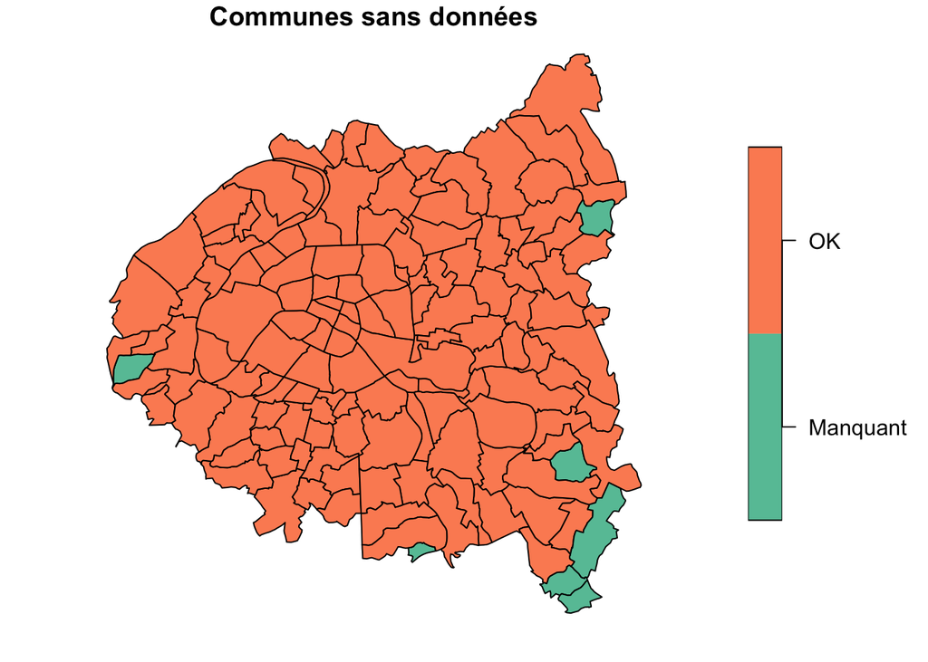

```r
# Chargement du tableau
indiv <- readRDS("ParisPC/RP2021/indiv2021.Rdata")

# Création de CSP simplifiées
indiv <- indiv %>%
  mutate(TACT5=case_when(TACT == "11" ~ "EMP",
                             TACT == "12" ~ "CHO",
                             TACT == "22" ~ "ETU",
                             TACT == "21" ~ "RET",
                             TRUE ~ "DIV"))

# Agrégation par IRIS
tab_com_csp  <- indiv %>%
                 mutate(com_code = substr(IRIS,1,5))%>%
                 group_by(com_code, TACT5) %>%
                 summarise(n = sum(IPONDI)) %>%
                 mutate(n=round(n)) %>%
                 pivot_wider(names_from = TACT5, values_from = n)

# Chargement du fonds de carte communal
map_com <- readRDS("ParisPC/geom/map_com.RDS")

# Jointure
map_com_csp <- left_join(map_com, tab_com_csp)

# Sauvegarde
saveRDS(map_com_csp, "ParisPC/geom/map_com_csp.RDS")

# Analyse des valeurs manquantes
map_com_csp$missing<-case_when(is.na(map_com_csp$CHO)  ~ "Manquant",
                                TRUE ~ "OK"
                               )
plot(map_com_csp["missing"], main= "Communes sans données")
```

On retrouve les 7 communes manquantes pour lesquelles l’INSEE ne fournit pas les données dans le fichier détail des individus.